# 3. Image import/export

For the moment, we have only used images that were provided internally by skimage. We are however normally going to use data located in the file system. The module skimage.io deals with all in/out operations and supports a variety of different import mechanisms.

```python
import numpy as np
import matplotlib.pyplot as plt
import skimage.io as io
```

## 3.1 Simple case

Most of the time the simples command imread() will do the job. One has just to specifiy the path of the file or a url. In general your path is going to look something like:

```
image = io.imread('/This/is/a/path/MyData/Klee.jpg')
```

```python
file_path = 'Data/Klee.jpg'
print(file_path)
```

```
Data/Klee.jpg
```

Here we only use a relative path, knowing that the `Data` folder is in the same folder as the notebook. However you can also give a complete path. We can also check what's the complete path of the current file:

```python
import os
print(os.path.realpath(file_path))
```

```
/home/marie/Documents/CAS_data_science/CAS_21.01.2020_Python_Image_Processing/PyImageCourse-master/Data/Klee.jpg
```

Now we can import the image:

```python
image = io.imread(file_path)
```

```python
image.shape
```

```
(643, 471, 3)
```

[figure not shown]

```python
plt.imshow(image);
```

Now with a url:

```python
image = io.imread('https://upload.wikimedia.org/wikipedia/commons/0/09/FluorescentCells.jpg')
```

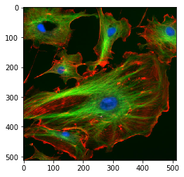

```python
plt.imshow(image)
plt.show()
```

## 3.2 Series of images (.tif)

Popular compressed formats such as jpg are usually used for natural images e.g. in facial recognition. The reason for that is that for those applications, in most situations one does not care about quantitative information and effects of information compression occurring in jpg are irrelevant. Also, those kind of data are rarely multi-dimensional (except for RGB).

In most other cases, the actual pixel intensity gives important information and one needs a format that preserves that information. Usually this is the .tif format or one of its many derivatives. One advantage is that the .tif format allows to save multiple images within a single file, a very useful feature for multi-dimensional acquisitions.

You might encounter different situations.

### 3.2.1 Series of separate images

In the first case, you would have multiple single .tif files within one folder. In that case, the file name usually contains indications about the content of the image, e.g a time point or a channel. The general way of dealing with this kind of situation is to use regular expressions, a powerful tool to parse information in text. This can be done in Python using the `re` module.

Here we will use an approach that identifies much simpler patterns.

Let's first see what files are contained within a folder of a microscopy experiment containing images acquired at two wavelengths using the `os` module:

```python
import glob
import os
```

```python
folder = 'Data/BBBC007_v1_images/A9'
```

Let's list all the files contained in the folder

```python
files = os.listdir(folder) # MZ: list all files that are within the directory
print(files)
```

```
['A9 p10f.tif', 'A9 p5f.tif', 'A9 p9d.tif', 'A9 p7f.tif', 'A9 p7d.tif', 'A9 p10d.tif', 'A9 p9f.tif', 'A9 p5d.tif']
```

The two channels are defined by the last character before .tif. Using the wild-card sign *we can define a pattern to select only the 'd' channel:* d.tif. We complete that name with the correct path. Now we use the native Python module `glob` to parse the folder content using this pattern:

```python
d_channel = glob.glob(folder+'/*d.tif')
d_channel
```

```
['Data/BBBC007_v1_images/A9/A9 p9d.tif',
 'Data/BBBC007_v1_images/A9/A9 p7d.tif',
 'Data/BBBC007_v1_images/A9/A9 p10d.tif',
 'Data/BBBC007_v1_images/A9/A9 p5d.tif']
```

Then we use again the `imread()` function to import a specific file:

```python
image1 = io.imread(d_channel[0])
```

```python
image1.shape
```

```
(450, 450)
```

[figure not shown]

```python
plt.imshow(image1);
```

These two steps can in principle be done in one step using the `imread_collection()` function of skimage.

We can also import all images and put them in list if we have sufficient memory:

```python
channel1_list = []
for x in d_channel:
    temp_im = io.imread(x)
    channel1_list.append(temp_im)
```

Let's see what we have in that list of images by plotting them:

```python
channel1_list[0].shape
```

```
(450, 450)
```

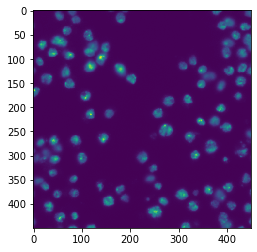

```python
plt.imshow(channel1_list[0]);
```

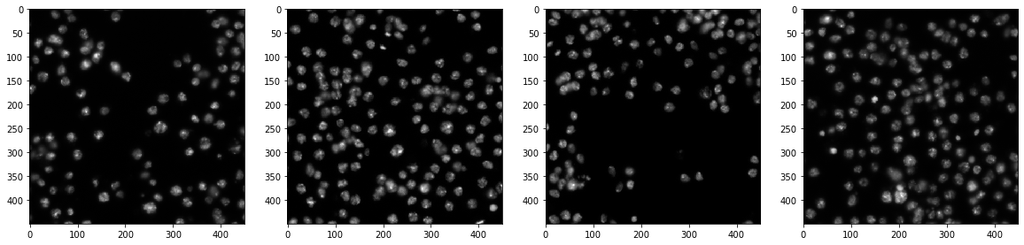

```python
num_plots = len(channel1_list)
plt.figure(figsize=(20,30))
for i in range(num_plots):
    plt.subplot(1,num_plots,i+1)
    plt.imshow(channel1_list[i],cmap = 'gray')
```

### 3.2.2 Multi-dimensional stacks

We now look at a more complex multi-dimensional case taken from a public dataset (J Cell Biol. 2010 Jan 11;188(1):49-68) that can be found [here](http://flagella.crbs.ucsd.edu/images/30567).

We already provide it in the datafolder:

```python
file = 'Data/30567/30567.tif'
# MZ: tif can contain many data and also can contain metadata -> very useful
```

```python
image = io.imread(file)
```

The dataset is a time-lapse 3D confocal microscopy acquired in two channels, one showing the location of tubulin, the other of lamin (cell nuclei).

All .tif variants have the same basic structure: single image planes are stored in individual "sub-directories" within the file. Some meta information is stored with each plane, some is stored for the entire file. However, how the different dimensions are ordered within the file (e.g. all time-points of a given channel first, or alternatively all channels of a given time-point) can vary wildly. The simplest solution is therefore usually to just import the file, look at the size of various dimensions and plot a few images to figure out how the data are organized.

```python
image.shape
```

```
(72, 2, 5, 512, 672)
```

We know we have two channels (dimension 2), and five planes (dimension 3). Usually the large numbers are the image dimension, and therefore 72 is probably the number of time-points. Using slicing, we look at the first time point, of both channels, of the first plane, and we indeed get an appropriate result:

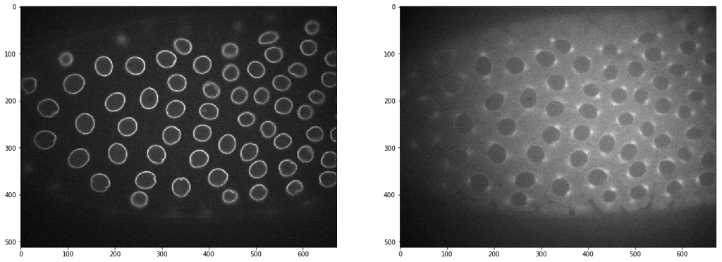

```python
plt.figure(figsize=(20,10))
plt.subplot(1,2,1)
plt.imshow(image[0,0,0,:,:],cmap = 'gray')
plt.subplot(1,2,2)
plt.imshow(image[0,1,0,:,:],cmap = 'gray');
```

We can check that our indexing works by checking the dimensions of the sliced image:

```python
# where are the metadata and how to access them -> data-specific
image[0,0,0,:,:].shape
```

```
(512, 672)
```

As we have seen in the Numpy chapter, we can do various operations on arrays. In particular we saw that we can do projections. Let's extract all planes of a given time point and channel:

```python
stack = image[0,0,:,:,:]
stack.shape
```

```
(5, 512, 672)
```

Here, to do a max projection, we now have to project all the planes along the **first** dimension, hence:

```python
maxproj = np.max(image[0,0,:,:,:],axis = 0)
#MZ:  1st time point, 1st channel, but all the planes; take all max along 1st dimension -> projection
# project on the 1st dimension (axis=0)
maxproj.shape
```

```
(512, 672)
```

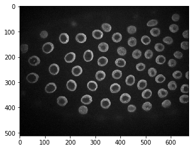

```python
plt.imshow(maxproj,cmap = 'gray')
plt.show()
```

skimage allows one to use specific import plug-ins for various applications (e.g. gdal for geographic data, FITS for astronomy etc.).

In particular it offers a lower-lever access to tif files through the tifffile module. This allows one for example to import only a subset of planes from the dataset if the latter is large.

```python
# load only what you want (e.g. the 1st time point)
# so you don't need to load all the timepoints in memory

# tif -> most often used format for this kind of data
```

```python
from skimage.external.tifffile import TiffFile

data = TiffFile(file)
```

Now the file is open but not imported, and one can query information about it. For example some metadata:

```python
data.info()
```

[output not shown]

Some specific planes:

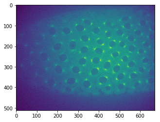

```python
plt.imshow(data.pages[6].asarray())
plt.show()
```

```python
image = [data.pages[x].asarray() for x in range(3)]
```

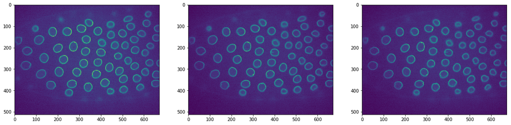

```python
plt.figure(figsize=(20,10))
for i in range(3):
    plt.subplot(1,3,i+1)
    plt.imshow(image[i])
plt.show()
```

### 3.2.3 Alternative formats

While a large majority of image formats is somehow based on tif, instrument providers often make their own tif version by creating a proprietary format. This is for example the case of the Zeiss microscopes which create the .czi format.

In almost all cases, you can find an dedicated library that allows you to open your particular file. For example for czi, there is a specific [package](https://pypi.org/project/czifile/).

More generally your research field might use some particular format. For example Geospatial data use the format GDAL, and for that there is of course a dedicated [package](https://pypi.org/project/GDAL/).

**Note that a lot of biology formats are well handled by the tifffile package. io.imread() tries to use the best plugin to open a format, but sometimes if fails. If you get an error using the default io.imread() you can try to specific what plugin should open the image, *.e.g***

```
image = io.imread(file, plugin='tifffile')
```

## 3.3 Exporting images

There are two ways to save images. Either as plain matrices, which can be written and re-loaded very fast, or as actual images.

Just like for loading, saving single planes is easy. Let us save a small region of one of the images above:

```python
image[0].shape
```

```
(512, 672)
```

```python
io.imsave('Data/region.tif',image[0][200:300,200:300])  # MZ: specify what you want to save
io.imsave('Data/region.jpg',image[0][200:300,200:300])
```

```python
reload_im = io.imread('Data/region.jpg') # MZ: jpg not good for scientific purposes
```

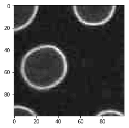

```python
plt.imshow(reload_im,cmap='gray')
plt.show()
```

Saving multi-dimensional .tif files is a bit more complicated as one has of course to be careful with the dimension order. Here again the tifffile module allows to achieve that task. We won't go through the details, but here's an example of how to save a dataset with two time poins, 5 stacks, 3 channels into a file that can then be opened as a hyper-stack in Fiji:

```python
from skimage.external.tifffile import TiffWriter

data = np.random.rand(2, 5, 3, 301, 219)#generate random images
data = (data*100).astype(np.uint8)#transform data in a reasonable 8bit range

with TiffWriter('Data/multiD_set.tif', bigtiff=False, imagej=True) as tif:
    for i in range(data.shape[0]):
        tif.save(data[i])
```

## 3.4 Interactive plotting

Jupyter offers a solution to interact with various types of plots: ipywidget

```python
from ipywidgets import interact, IntSlider
```

The interact() function takes as input a function and a value for that function. That function should plot or print some information. interact() then creates a widget, typically a slider, executes the plotting function and adjusts the ouptut when the slider is moving. For example:

```python
def square(num=1):
    print(str(num)+' squared is: '+str(num*num))
```

```python
square(3)
```

```
3 squared is: 9
```

```python
interact(square, num=(0,20,1));
```

Depending on the values passed as arugments, interact() will create different widgets. E.g. with text:

```python
def f(x):
    return x
interact(f, x='Hi there!');
```

An important note for our imaging topic: when moving the slider, the function is continuously updated. If the function does some computationally intensitve work, this might just overload the system. To avoid that, one can explicitly specifiy the slider type and its specificities:

```python
def square(num=1):
    print(str(num)+' squared is: '+str(num*num))
interact(square, num = IntSlider(min=-10,max=30,step=1,value=10,continuous_update = False));
```

If we want to scroll through our image stack we can do just that. Let's first define a function that will plot the first plane of the channel 1 at all time points:

```python
image = io.imread(file)
```

```python
def plot_plane(t):
    plt.imshow(image[t,0,0,:,:])
    plt.show()
```

```python
interact(plot_plane, t = IntSlider(min=0,max=71,step=1,value=0,continuous_update = False));
```

Of course we can do that for multiple dimensions:

```python
def plot_plane(t,c,z):
    plt.imshow(image[t,c,z,:,:])
    plt.show()

interact(plot_plane, t = IntSlider(min=0,max=71,step=1,value=0,continuous_update = True),
         c = IntSlider(min=0,max=1,step=1,value=0,continuous_update = True),
         z = IntSlider(min=0,max=4,step=1,value=0,continuous_update = True));
```

And we can make it as fancy as we want:

```python
def plot_plane(t,c,z):
    if c == 0:
        plt.imshow(image[t,c,z,:,:], cmap = 'Reds')
    else:
        plt.imshow(image[t,c,z,:,:], cmap = 'Blues')
    plt.show()

interact(plot_plane, t = IntSlider(min=0,max=71,step=1,value=0,continuous_update = True),
         c = IntSlider(min=0,max=1,step=1,value=0,continuous_update = True),
         z = IntSlider(min=0,max=4,step=1,value=0,continuous_update = True));
```